# Proyecto EasyVisa

## Contexto:

Las comunidades empresariales en los Estados Unidos se enfrentan a una gran demanda de recursos humanos, pero uno de los desafíos constantes es identificar y atraer el talento adecuado, que es quizás el elemento más importante para seguir siendo competitivo. Las empresas en los Estados Unidos buscan personas trabajadoras, talentosas y calificadas tanto a nivel local como en el extranjero.

La Ley de Inmigración y Nacionalidad (INA) de los EE. UU. permite que los trabajadores extranjeros vengan a los Estados Unidos a trabajar de manera temporal o permanente. La ley también protege a los trabajadores estadounidenses contra impactos adversos en sus salarios o condiciones de trabajo al garantizar el cumplimiento de los requisitos legales por parte de los empleadores estadounidenses cuando contratan trabajadores extranjeros para cubrir la escasez de mano de obra. Los programas de inmigración son administrados por la Oficina de Certificación de Trabajo Extranjero (OFLC).

OFLC procesa las solicitudes de certificación laboral para los empleadores que buscan traer trabajadores extranjeros a los Estados Unidos y otorga certificaciones en aquellos casos en los que los empleadores pueden demostrar que no hay suficientes trabajadores estadounidenses disponibles para realizar el trabajo con salarios que alcanzan o superan el salario pagado por la ocupación. en el área de empleo previsto.

## Objetivo:

En el año fiscal 2016, la OFLC procesó 775 979 solicitudes de empleadores para 1 699 957 puestos para certificaciones laborales temporales y permanentes. Este fue un aumento del nueve por ciento en el número total de solicitudes procesadas con respecto al año anterior. El proceso de revisión de cada caso se está convirtiendo en una tarea tediosa ya que el número de solicitantes aumenta cada año.

El creciente número de solicitantes cada año requiere una solución basada en aprendizaje automático que pueda ayudar a preseleccionar a los candidatos que tienen mayores posibilidades de aprobación de VISA. OFLC ha contratado a su empresa EasyVisa para soluciones basadas en datos. Usted, como científico de datos, debe analizar los datos proporcionados y, con la ayuda de un modelo de clasificación:

*Facilitar el proceso de aprobación de visas.* Recomendar un perfil adecuado para los solicitantes a quienes se les debe certificar o denegar la visa en función de los factores que influyen significativamente en el estado del caso.

## Datos Descripción

Los datos contienen los diferentes atributos del empleado y del empleador. El diccionario de datos detallado se proporciona a continuación.

- case_id: ID de cada solicitud de visa
- continent: Información del continente del empleado
- education_of_employee: Información de educación del empleado
- has_job_experience: ¿El empleado tiene alguna experiencia laboral? S= Sí; N = No
- require_job_training: ¿El empleado requiere alguna capacitación laboral? S = Sí; N = No
- no_de_employees: Número de empleados en la empresa del empleador
- yr_of_estab: Año en que se constituyó la empresa del empleador
- region_of_employment:: información de la región prevista de empleo del trabajador extranjero en los EE. UU.
- prevailing_wage: Salario promedio pagado a trabajadores empleados de manera similar en una ocupación específica en el área de empleo prevista. El propósito del salario prevaleciente es asegurar que el trabajador extranjero no esté mal pagado en comparación con otros trabajadores que ofrecen el mismo servicio o un servicio similar en la misma área de empleo.
- unit_of_wage: Unidad de salario prevaleciente. Los valores incluyen por salario por hora, Semanal, Mensual y Anual.
- full_time_position: ¿El puesto de trabajo es de tiempo completo? Y = Puesto de tiempo completo; N = Puesto a tiempo parcial
- case_status: Indicador que indica si la Visa fue certificada o denegada

## Importación de bibliotecas y datos necesarios

```python
import warnings

warnings.filterwarnings("ignore")

# Libraries to help with reading and manipulating data
import numpy as np
import pandas as pd

# Library to split data
from sklearn.model_selection import train_test_split

# libaries to help with data visualization
import matplotlib.pyplot as plt
import seaborn as sns

# Removes the limit for the number of displayed columns
pd.set_option("display.max_columns", None)
# Sets the limit for the number of displayed rows
pd.set_option("display.max_rows", 100)


# Libraries different ensemble classifiers
from sklearn.ensemble import (
    BaggingClassifier,
    RandomForestClassifier,
    AdaBoostClassifier,
    GradientBoostingClassifier,
    StackingClassifier,
)

from xgboost import XGBClassifier
from sklearn.tree import DecisionTreeClassifier

# Libraries to get different metric scores
from sklearn import metrics
from sklearn.metrics import (
    confusion_matrix,
    accuracy_score,
    precision_score,
    recall_score,
    f1_score,
)

# To tune different models
from sklearn.model_selection import GridSearchCV
```

```python
!pip install xgboost
```

```python
visa = pd.read_csv('EasyVisa.csv')
```

```python
data = visa.copy()
```

## Resumen de datos

- Observaciones
- Controles de cordura

```python
data.head()
```

|  | case_id | continent | education_of_employee | has_job_experience | requires_job_training | no_of_employees | yr_of_estab | region_of_employment | prevailing_wage | unit_of_wage | full_time_position | case_status |
| --- | --- | --- | --- | --- | --- | --- | --- | --- | --- | --- | --- | --- |
| 0 | EZYV01 | Asia | High School | N | N | 14513 | 2007 | West | 592.2029 | Hour | Y | Denied |
| 1 | EZYV02 | Asia | Master's | Y | N | 2412 | 2002 | Northeast | 83425.6500 | Year | Y | Certified |
| 2 | EZYV03 | Asia | Bachelor's | N | Y | 44444 | 2008 | West | 122996.8600 | Year | Y | Denied |
| 3 | EZYV04 | Asia | Bachelor's | N | N | 98 | 1897 | West | 83434.0300 | Year | Y | Denied |
| 4 | EZYV05 | Africa | Master's | Y | N | 1082 | 2005 | South | 149907.3900 | Year | Y | Certified |

```python
data.tail()
```

|  | case_id | continent | education_of_employee | has_job_experience | requires_job_training | no_of_employees | yr_of_estab | region_of_employment | prevailing_wage | unit_of_wage | full_time_position | case_status |
| --- | --- | --- | --- | --- | --- | --- | --- | --- | --- | --- | --- | --- |
| 25475 | EZYV25476 | Asia | Bachelor's | Y | Y | 2601 | 2008 | South | 77092.57 | Year | Y | Certified |
| 25476 | EZYV25477 | Asia | High School | Y | N | 3274 | 2006 | Northeast | 279174.79 | Year | Y | Certified |
| 25477 | EZYV25478 | Asia | Master's | Y | N | 1121 | 1910 | South | 146298.85 | Year | N | Certified |
| 25478 | EZYV25479 | Asia | Master's | Y | Y | 1918 | 1887 | West | 86154.77 | Year | Y | Certified |
| 25479 | EZYV25480 | Asia | Bachelor's | Y | N | 3195 | 1960 | Midwest | 70876.91 | Year | Y | Certified |

```python
print("There are", data.shape[0], 'rows and', data.shape[1], "columns.")
```

```
There are 25480 rows and 12 columns.
```

```python
data.info()
```

```
<class 'pandas.core.frame.DataFrame'>
RangeIndex: 25480 entries, 0 to 25479
Data columns (total 12 columns):
 #   Column                 Non-Null Count  Dtype
---  ------                 --------------  -----
 0   case_id                25480 non-null  object
 1   continent              25480 non-null  object
 2   education_of_employee  25480 non-null  object
 3   has_job_experience     25480 non-null  object
 4   requires_job_training  25480 non-null  object
 5   no_of_employees        25480 non-null  int64
 6   yr_of_estab            25480 non-null  int64
 7   region_of_employment   25480 non-null  object
 8   prevailing_wage        25480 non-null  float64
 9   unit_of_wage           25480 non-null  object
 10  full_time_position     25480 non-null  object
 11  case_status            25480 non-null  object
dtypes: float64(1), int64(2), object(9)
memory usage: 2.3+ MB
```

Aqui podemos visualizar el tipo de datos que hay en el df y la cantidad de observaciones que tienen las variables.

```python
data.isnull().sum()
```

```
case_id                  0
continent                0
education_of_employee    0
has_job_experience       0
requires_job_training    0
no_of_employees          0
yr_of_estab              0
region_of_employment     0
prevailing_wage          0
unit_of_wage             0
full_time_position       0
case_status              0
dtype: int64
```

Podemos ver que este df no cuenta con valores perdidos ni duplicados.

```python
data.describe(include ='all').T
```

[output not shown]

```python
data["no_of_employees"] = data["no_of_employees"].abs()
```

previamente se visualizo que la varibale "no_of_employees" cuenta con valores negativos, utilizaremos .abs() para utilizar su valor absoluto.

```python
cat_col = list(data.select_dtypes("object").columns)


for column in cat_col:
    print(data[column].value_counts())
    print("-" * 50)
```

```
EZYV01       1
EZYV16995    1
EZYV16993    1
EZYV16992    1
EZYV16991    1
            ..
EZYV8492     1
EZYV8491     1
EZYV8490     1
EZYV8489     1
EZYV25480    1
Name: case_id, Length: 25480, dtype: int64
--------------------------------------------------
Asia             16861
Europe            3732
North America     3292
South America      852
Africa             551
Oceania            192
Name: continent, dtype: int64
--------------------------------------------------
Bachelor's     10234
Master's        9634
High School     3420
Doctorate       2192
Name: education_of_employee, dtype: int64
--------------------------------------------------
Y    14802
N    10678
Name: has_job_experience, dtype: int64
--------------------------------------------------
N    22525
Y     2955
Name: requires_job_training, dtype: int64
--------------------------------------------------
Northeast    7195
South        7017
West         6586
Midwest      4307
Island        375
Name: region_of_employment, dtype: int64
--------------------------------------------------
Year     22962
Hour      2157
Week       272
Month       89
Name: unit_of_wage, dtype: int64
--------------------------------------------------
Y    22773
N     2707
Name: full_time_position, dtype: int64
--------------------------------------------------
Certified    17018
Denied        8462
Name: case_status, dtype: int64
--------------------------------------------------
```

```python
data["case_id"].nunique()
```

```
25480
```

```python
data.drop(["case_id"], axis=1, inplace=True)
```

Se elimina la variable "case_id" ya que solo cuenta con valores unicos

## Análisis exploratorio de datos (EDA)

- EDA es una parte importante de cualquier proyecto que involucre datos.
- Es importante investigar y comprender mejor los datos antes de construir un modelo con ellos.
- A continuación se mencionan algunas preguntas que lo ayudarán a abordar el análisis de la manera correcta y generar conocimientos a partir de los datos.
- Se debe realizar un análisis exhaustivo de los datos, además de las preguntas que se mencionan a continuación.

**Preguntas capciosas**:

1. Las personas con educación superior pueden querer viajar al extranjero por un trabajo bien remunerado. ¿La educación juega un papel en la certificación de Visa?
2. ¿Cómo varía el estado de la visa en los diferentes continentes?
3. Los profesionales experimentados pueden buscar oportunidades en el extranjero para mejorar su estilo de vida y desarrollo profesional. ¿La experiencia laboral influye en el estado de la visa?
4. En los Estados Unidos, a los empleados se les paga en diferentes intervalos. ¿Qué unidad de pago es más probable que se certifique para una visa?
5. El gobierno de los Estados Unidos ha establecido un salario prevaleciente para proteger el talento local y los trabajadores extranjeros. ¿Cómo cambia el estado de la visa con el salario prevaleciente?

### Analisis univariado

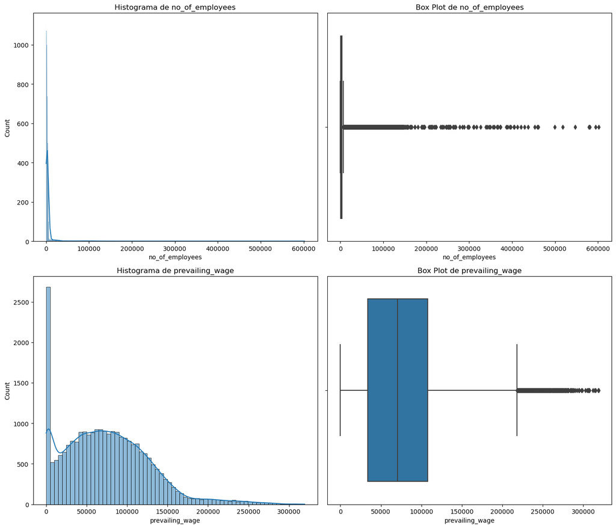

```python
# Lista de atributos que deseas visualizar
attributes_to_visualize = [
    'no_of_employees', 'prevailing_wage'
]

# Configuración de la figura y los ejes
num_rows = len(attributes_to_visualize)
fig, axes = plt.subplots(nrows=num_rows, ncols=2, figsize=(14, num_rows * 6))
plt.subplots_adjust(hspace=0.5)

# Creación de histogramas y box plots para cada atributo
for i, attribute in enumerate(attributes_to_visualize):
    sns.histplot(data[attribute], ax=axes[i, 0], kde=True)
    axes[i, 0].set_title(f'Histograma de {attribute}')

    sns.boxplot(x=data[attribute], ax=axes[i, 1])
    axes[i, 1].set_title(f'Box Plot de {attribute}')

# Mostrar las visualizaciones
plt.tight_layout()
plt.show()
```

```python
data.loc[data["prevailing_wage"] < 100, "unit_of_wage"].value_counts()
```

```
Hour    176
Name: unit_of_wage, dtype: int64
```

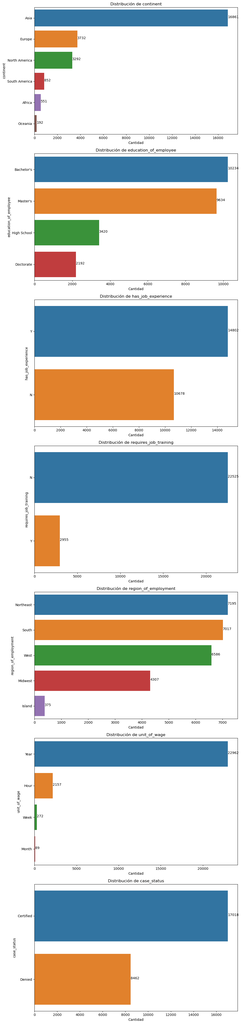

```python
# Lista de variables categóricas para visualizar
categorical_variables = ['continent', 'education_of_employee', 'has_job_experience', 'requires_job_training', 'region_of_employment', 'unit_of_wage', 'case_status']
# Configuración de la figura y los ejes
num_rows = len(categorical_variables)
fig, axes = plt.subplots(nrows=num_rows, figsize=(10, num_rows * 6))
plt.subplots_adjust(hspace=0.5)

# Creación de gráficos de barras etiquetados
for i, variable in enumerate(categorical_variables):
    sns.countplot(data=data, y=variable, ax=axes[i], order=data[variable].value_counts().index)
    axes[i].set_title(f'Distribución de {variable}')
    axes[i].set_ylabel(variable)
    axes[i].set_xlabel('Cantidad')

    for p in axes[i].patches:
        count = int(p.get_width())
        x = p.get_x() + p.get_width() + 0.02
        y = p.get_y() + p.get_height() / 2
        axes[i].annotate(count, (x, y))

# Mostrar las visualizaciones
plt.tight_layout()
plt.show()
```

> continet: Podemos observar que Asia es el continente de donde vienen más empleados, seguido por Europa y norteamérica

> education_of_employee: Podemos ver que la mayoria de los empleados cuenta con un bachelors degree y un masters degree.

> has_job_experience: La mayoria de los empleados cuenta con experiencia laboral.

> requires_job_training: Se observa que la mayoria de los empleados no necesitan entrenamiento.

> region_of_employment: Las 3 regiones más previstas por los trabajadores son: Northeast, south y west.

> unit_of_wage: Podemos observar la froma principal de pago de salario para los trabajadores es por año.

> case_status: Se puede observar que la mayoria de los casos se certifica la visa.

### Analisis bivariado

```python
def distribution_plot_wrt_target(data, predictor, target):

    fig, axs = plt.subplots(2, 2, figsize=(12, 10))

    target_uniq = data[target].unique()

    axs[0, 0].set_title("Distribution of target for target=" + str(target_uniq[0]))
    sns.histplot(
        data=data[data[target] == target_uniq[0]],
        x=predictor,
        kde=True,
        ax=axs[0, 0],
        color="teal",
        stat="density",
    )

    axs[0, 1].set_title("Distribution of target for target=" + str(target_uniq[1]))
    sns.histplot(
        data=data[data[target] == target_uniq[1]],
        x=predictor,
        kde=True,
        ax=axs[0, 1],
        color="orange",
        stat="density",
    )

    axs[1, 0].set_title("Boxplot w.r.t target")
    sns.boxplot(data=data, x=target, y=predictor, ax=axs[1, 0], palette="gist_rainbow")

    axs[1, 1].set_title("Boxplot (without outliers) w.r.t target")
    sns.boxplot(
        data=data,
        x=target,
        y=predictor,
        ax=axs[1, 1],
        showfliers=False,
        palette="gist_rainbow",
    )

    plt.tight_layout()
    plt.show()
```

```python
def stacked_barplot(data, predictor, target):
    """
    Print the category counts and plot a stacked bar chart

    data: dataframe
    predictor: independent variable
    target: target variable
    """
    count = data[predictor].nunique()
    sorter = data[target].value_counts().index[-1]
    tab1 = pd.crosstab(data[predictor], data[target], margins=True).sort_values(
        by=sorter, ascending=False
    )
    print(tab1)
    print("-" * 120)
    tab = pd.crosstab(data[predictor], data[target], normalize="index").sort_values(
        by=sorter, ascending=False
    )
    tab.plot(kind="bar", stacked=True, figsize=(count + 5, 5))
    plt.legend(
        loc="lower left", frameon=False,
    )
    plt.legend(loc="upper left", bbox_to_anchor=(1, 1))
    plt.show()
```

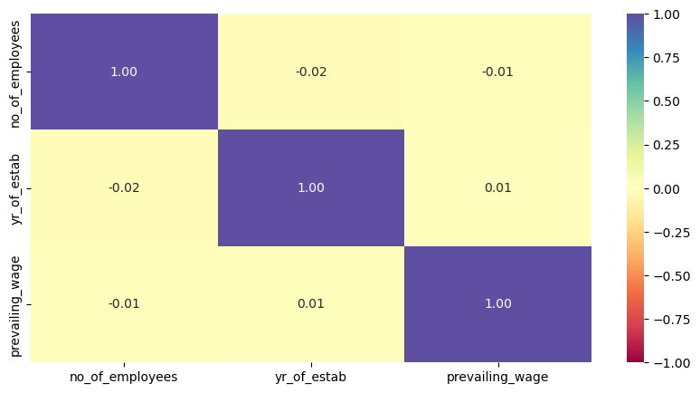

```python
cols_list = data.select_dtypes(include=np.number).columns.tolist()

plt.figure(figsize=(10, 5))
sns.heatmap(
    data[cols_list].corr(), annot=True, vmin=-1, vmax=1, fmt=".2f", cmap="Spectral"
) ## Complete the code to find the correlation between the variables
plt.show()
```

Se puede observar que no hay una correlacion marcada entre las variables, por lo cual no tendremos problemas de multicolinealidad.

#### Las personas con educación superior pueden querer viajar al extranjero por un trabajo bien remunerado. ¿La educación juega un papel en la certificación de Visa?

```
case_status            Certified  Denied    All
education_of_employee
All                        17018    8462  25480
Bachelor's                  6367    3867  10234
High School                 1164    2256   3420
Master's                    7575    2059   9634
Doctorate                   1912     280   2192
------------------------------------------------------------------------------------------------------------------------
```

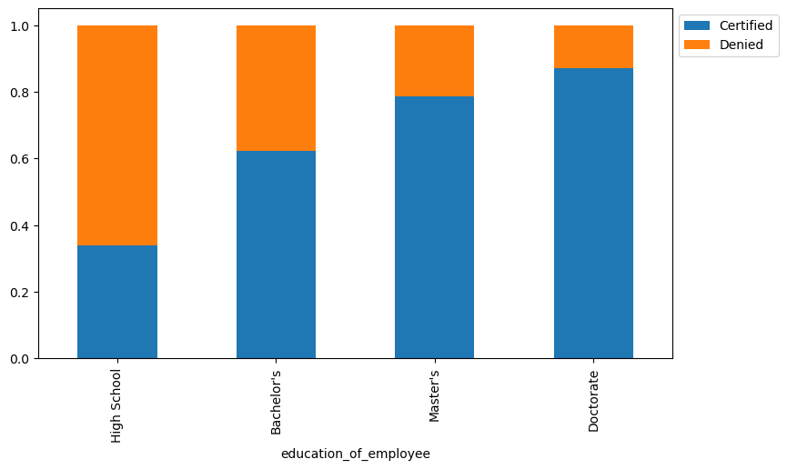

```python
stacked_barplot(data, "education_of_employee", "case_status")
```

La educación desempeña un papel significativo en la certificación de visas. Los datos muestran claramente una tendencia en la que a medida que el nivel de educación del solicitante aumenta, también lo hace la probabilidad de que su visa sea certificada. Por ejemplo, mientras que solo el 34% de los solicitantes con educación de nivel secundaria recibieron una visa, un impresionante 87% de los solicitantes con un doctorado lograron la certificación. Esto sugiere que las personas con educación superior tienen una mayor probabilidad de obtener la certificación de visa, posiblemente debido a la percepción de habilidades especializadas o experiencia que pueden aportar al mercado laboral de EE.UU.

#### ¿Cómo varía el estado de la visa en los diferentes continentes?

```
case_status    Certified  Denied    All
continent
All                17018    8462  25480
Asia               11012    5849  16861
North America       2037    1255   3292
Europe              2957     775   3732
South America        493     359    852
Africa               397     154    551
Oceania              122      70    192
------------------------------------------------------------------------------------------------------------------------
```

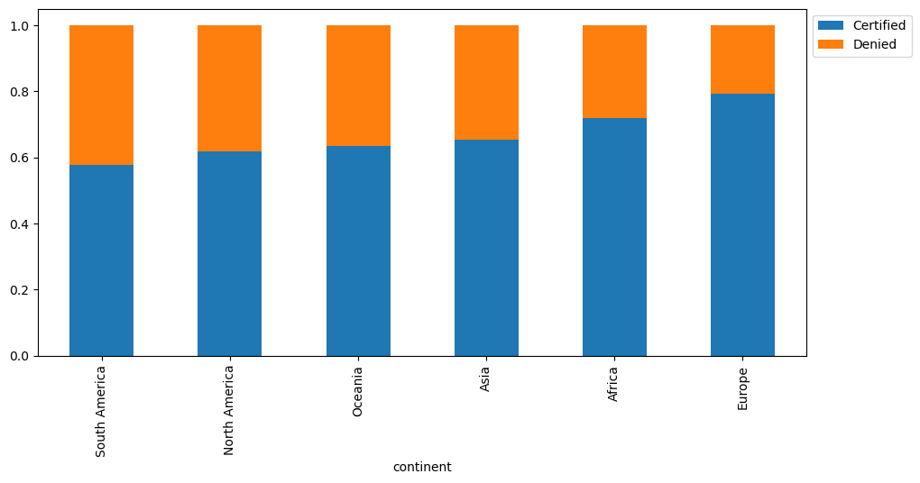

```python
stacked_barplot(data, 'continent', 'case_status')
```

Los solicitantes de visa de Europa tienen la mayor tasa de aprobación con un 79%, mientras que los de Sudamérica tienen la más baja con un 58%. Aunque Asia tuvo la mayor cantidad de solicitantes, su tasa de aprobación fue del 65%. Estas diferencias podrían deberse a varios factores, como oportunidades laborales o relaciones entre países. Es importante analizar más a fondo para entender completamente estas variaciones.

#### Los profesionales experimentados pueden buscar oportunidades en el extranjero para mejorar su estilo de vida y desarrollo profesional. ¿La experiencia laboral influye en el estado de la visa?

```
case_status         Certified  Denied    All
has_job_experience
All                     17018    8462  25480
N                        5994    4684  10678
Y                       11024    3778  14802
------------------------------------------------------------------------------------------------------------------------
```

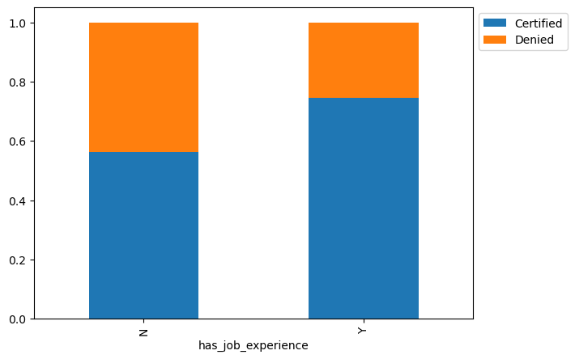

```python
stacked_barplot(data, 'has_job_experience', 'case_status')
```

La experiencia laboral parece tener un impacto significativo en la aprobación de visas. Los solicitantes con experiencia laboral tienen una tasa de aprobación del 74%, considerablemente más alta que aquellos sin experiencia, cuya tasa es del 56%. Esto sugiere que tener experiencia laboral mejora las chances de obtener una visa, posiblemente porque los empleadores en EE.UU. valoran la experiencia previa en el campo.

#### En los Estados Unidos, a los empleados se les paga en diferentes intervalos. ¿Qué unidad de pago es más probable que se certifique para una visa?

```
case_status   Certified  Denied    All
unit_of_wage
All               17018    8462  25480
Year              16047    6915  22962
Hour                747    1410   2157
Week                169     103    272
Month                55      34     89
------------------------------------------------------------------------------------------------------------------------
```

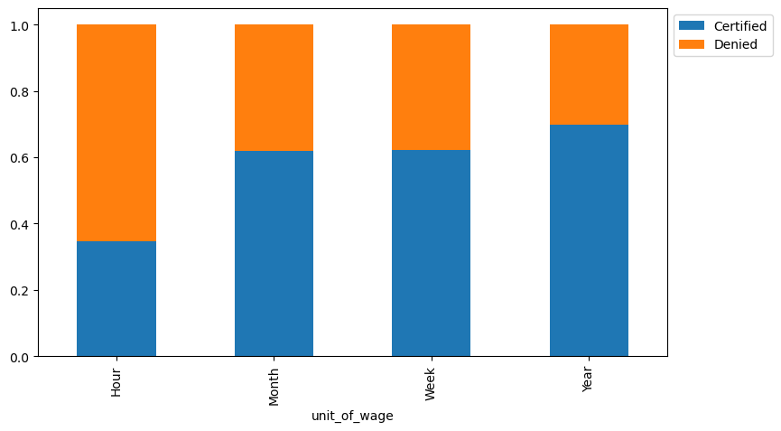

```python
stacked_barplot(data, 'unit_of_wage', 'case_status')
```

Los solicitantes que tienen un salario propuesto basado en un pago anual tienen la mayor probabilidad de que se les certifique una visa, con una tasa de aprobación del 70%. Por otro lado, aquellos con un pago propuesto por hora tienen la tasa de aprobación más baja, con solo el 34.6%. Esto podría indicar que los empleadores en EE.UU. muestran una preferencia o confianza hacia los roles que ofrecen compensación anual en lugar de aquellos que pagan por hora cuando se trata de contratar trabajadores extranjeros.

#### El gobierno de los Estados Unidos ha establecido un salario prevaleciente para proteger el talento local y los trabajadores extranjeros. ¿Cómo cambia el estado de la visa con el salario prevaleciente?

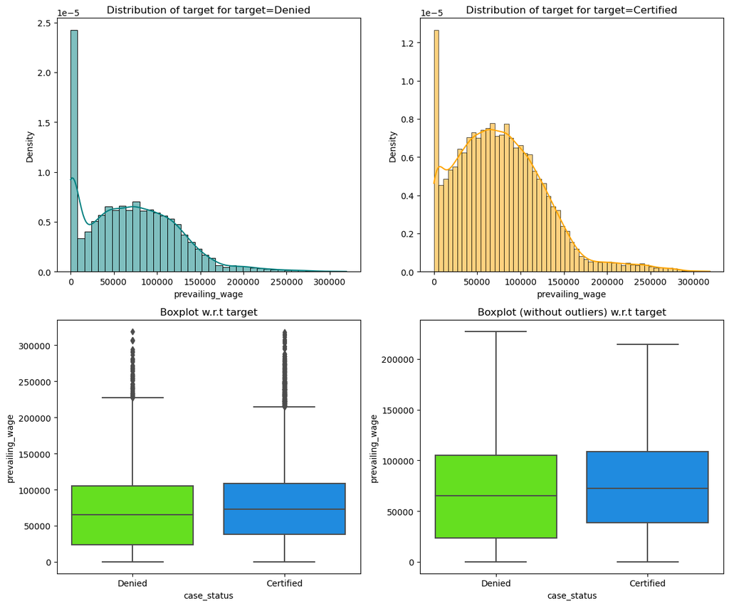

```python
distribution_plot_wrt_target(data, 'prevailing_wage', 'case_status')
```

```python
bins = [0, 30000, 60000, 90000, 120000, float("inf")]
labels = ["<30k", "30k-60k", "60k-90k", "90k-120k", ">120k"]

data['wage_category'] = pd.cut(data['prevailing_wage'], bins=bins, labels=labels, right=False)

# Luego, creamos una tabla cruzada para ver el estado de la visa por categoría de salario
result = pd.crosstab(data['wage_category'], data['case_status'], margins=True, margins_name="All")

print(result)
```

[output not shown]

La tasa de aprobación de visas parece aumentar con el salario prevaleciente hasta el rango de 60k-90k, manteniéndose bastante constante en los rangos más altos. Sin embargo, las personas con salarios inferiores a 30k tienen la tasa de aprobación más baja, con solo el 58%. Esto sugiere que los solicitantes con salarios más altos prevalecientes, lo que podría indicar roles más especializados o en demanda, tienen una mayor probabilidad de que se les certifique una visa.

## Preprocesamiento de datos

- Tratamiento de valor perdido (si es necesario)
- Ingeniería de características
- Detección y tratamiento de valores atípicos (si es necesario)
- Preparación de datos para el modelado.
- Cualquier otro paso de preprocesamiento (si es necesario)

### Valores atipicos

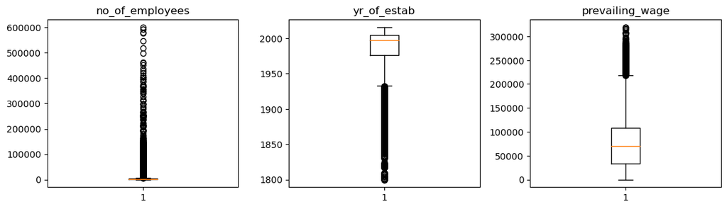

```python
# outlier detection using boxplot
numeric_columns = data.select_dtypes(include=np.number).columns.tolist()


plt.figure(figsize=(15, 12))

for i, variable in enumerate(numeric_columns):
    plt.subplot(4, 4, i + 1)
    plt.boxplot(data[variable], whis=1.5)
    plt.tight_layout()
    plt.title(variable) ## Complete the code to create boxplots for all the numeric columns
plt.show()
```

Hay bastantes valores atípicos en los datos. Sin embargo, no los trataremos como si fueran valores propios

## EDA

- Es una buena idea explorar los datos una vez más después de manipularlos.

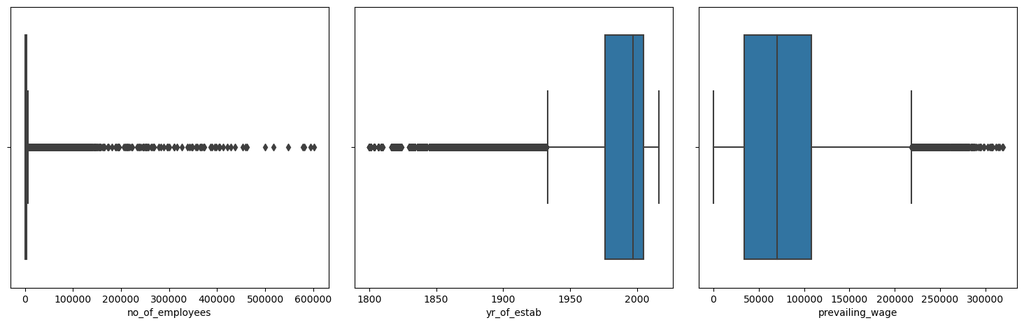

```python
# Columnas numéricas en el DataFrame
num_cols = data.select_dtypes(include=np.number).columns.tolist()

# Ajusta el número de filas y columnas según la cantidad de variables
num_rows = int(np.ceil(len(num_cols) / 3))
num_cols_subplot = min(len(num_cols), 3)

plt.figure(figsize=(15, num_rows * 5))

for i, variable in enumerate(num_cols):
    plt.subplot(num_rows, num_cols_subplot, i + 1)
    sns.boxplot(data=data, x=variable)
    plt.tight_layout(pad=2)
```

Al examinar los boxplots generados podemos obtener valiosa información sobre la distribución y variabilidad de estos atributos. Las boxplots nos permiten observar la mediana, los cuartiles y la presencia de valores atípicos en las variables.

### Preparación de datos para el modelado

```python
data["case_status"] = data["case_status"].apply(lambda x: 1 if x == "Certified" else 0)

X = data.drop(['case_status'], axis=1)
Y = data["case_status"]


X = pd.get_dummies(X, drop_first=True)

# Splitting data in train and test sets
X_train, X_test, y_train, y_test = train_test_split(X, Y, test_size=0.30, random_state=1, stratify=Y)
```

```python
print("Shape of Training set : ", X_train.shape)
print("Shape of test set : ", X_test.shape)
print("Percentage of classes in training set:")
print(y_train.value_counts(normalize=True))
print("Percentage of classes in test set:")
print(y_test.value_counts(normalize=True))
```

```
Shape of Training set :  (17836, 21)
Shape of test set :  (7644, 21)
Percentage of classes in training set:
1    0.667919
0    0.332081
Name: case_status, dtype: float64
Percentage of classes in test set:
1    0.667844
0    0.332156
Name: case_status, dtype: float64
```

## Criterio de evaluación del modelo

### El modelo puede hacer predicciones incorrectas como:

1. El modelo predice que la solicitud de visa se certificará, pero en realidad, la solicitud de visa debería ser denegada.
2. El modelo predice que la solicitud de visa no se certificará, pero en realidad, la solicitud de visa debería certificarse.

### ¿Qué caso es más importante?

- Tanto los casos son importantes como:
- Si se certifica una visa cuando tuvo que ser denegada, un empleado equivocado obtendrá el puesto de trabajo, mientras que los ciudadanos estadounidenses perderán la oportunidad de trabajar en ese puesto.
- Si se niega una visa cuando tenía que ser certificada, los EE. UU. perderán un recurso humano adecuado que puede contribuir a la economía.

### ¿Cómo reducir las pérdidas?

- La `Puntuación F1` se puede utilizar como métrica para la evaluación del modelo, cuanto mayor sea la puntuación F1, mayores serán las posibilidades de minimizar los falsos negativos y los falsos positivos.
- Usaremos ponderaciones de clases equilibradas para que el modelo se centre por igual en ambas clases.

**Primero, creemos funciones para calcular diferentes métricas y matrices de confusión para que no tengamos que usar el mismo código repetidamente para cada modelo.**

- La función model_performance_classification_sklearn se utilizará para verificar el rendimiento del modelo de los modelos.
- La función confusion_matrix_sklearn se utilizará para trazar la matriz de confusión.

```python
def model_performance_classification_sklearn(model, predictors, target):
    """
    Function to compute different metrics to check classification model performance

    model: classifier
    predictors: independent variables
    target: dependent variable
    """

    # predicting using the independent variables
    pred = model.predict(predictors)

    acc = accuracy_score(target, pred)  # to compute Accuracy
    recall = recall_score(target, pred)  # to compute Recall
    precision = precision_score(target, pred)  # to compute Precision
    f1 = f1_score(target, pred)  # to compute F1-score

    # creating a dataframe of metrics
    df_perf = pd.DataFrame(
        {"Accuracy": acc, "Recall": recall, "Precision": precision, "F1": f1,},
        index=[0],
    )

    return df_perf
```

```python
def confusion_matrix_sklearn(model, predictors, target):
    """
    To plot the confusion_matrix with percentages

    model: classifier
    predictors: independent variables
    target: dependent variable
    """
    y_pred = model.predict(predictors)
    cm = confusion_matrix(target, y_pred)
    labels = np.asarray(
        [
            ["{0:0.0f}".format(item) + "\n{0:.2%}".format(item / cm.flatten().sum())]
            for item in cm.flatten()
        ]
    ).reshape(2, 2)

    plt.figure(figsize=(6, 4))
    sns.heatmap(cm, annot=labels, fmt="")
    plt.ylabel("True label")
    plt.xlabel("Predicted label")
```

## Árbol de decisiones: construcción de modelos y ajuste de hiperparámetros

### Decision Tree

```python
model = DecisionTreeClassifier(random_state=1)
model.fit(X_train, y_train)
```

```
DecisionTreeClassifier(random_state=1)
```

#### Comprobación del rendimiento del modelo en el conjunto de entrenamiento

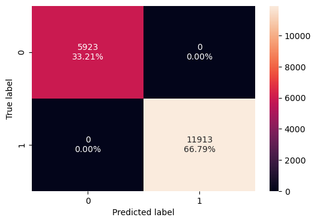

```python
confusion_matrix_sklearn(model, X_train, y_train)
```

```python
decision_tree_perf_train = model_performance_classification_sklearn(model, X_train, y_train)
decision_tree_perf_train
```

|  | Accuracy | Recall | Precision | F1 |
| --- | --- | --- | --- | --- |
| 0 | 1.0 | 1.0 | 1.0 | 1.0 |

#### Comprobación del rendimiento del modelo en el conjunto de prueba

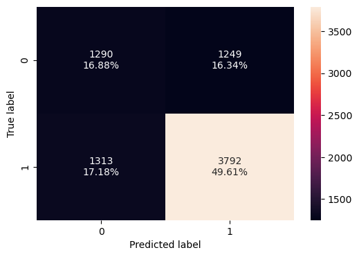

```python
confusion_matrix_sklearn(model, X_test, y_test)
```

```python
decision_tree_perf_test = model_performance_classification_sklearn(model, X_test, y_test)
decision_tree_perf_test
```

|  | Accuracy | Recall | Precision | F1 |
| --- | --- | --- | --- | --- |
| 0 | 0.664835 | 0.742801 | 0.752232 | 0.747487 |

Árbol de Decisiones sin Ajustar:

- Conjunto de Entrenamiento:

El modelo ha demostrado un rendimiento óptimo en todas las métricas (Exactitud, Sensibilidad, Precisión, F1: todos 1.0).

- Conjunto de Prueba:

Se observa una reducción en el rendimiento (Exactitud: 0.6648, Sensibilidad: 0.7428, Precisión: 0.7522, F1: 0.7475).

- Observaciones: El modelo, en su configuración actual, muestra síntomas de sobreajuste en el conjunto de entrenamiento. A pesar de su rendimiento perfecto durante la fase de entrenamiento, no logra generalizar adecuadamente en el conjunto de prueba. Es imperativo considerar ajustes para mejorar su capacidad de generalización.

### Ajuste de hiperparámetros - dtree

```python
# Choose the type of classifier.
dtree_estimator = DecisionTreeClassifier(class_weight="balanced", random_state=1)

# Grid of parameters to choose from
parameters = {
    "max_depth": np.arange(5, 16, 5),
    "min_samples_leaf": [3, 5, 7],
    "max_leaf_nodes": [2, 5],
    "min_impurity_decrease": [0.0001, 0.001],
}

# Type of scoring used to compare parameter combinations
scorer = metrics.make_scorer(metrics.f1_score)

# Run the grid search
grid_obj = GridSearchCV(dtree_estimator, parameters, scoring=scorer, n_jobs=-1)
grid_obj = grid_obj.fit(X_train, y_train)


dtree_estimator = grid_obj.best_estimator_

# Fit the best algorithm to the data.
dtree_estimator.fit(X_train, y_train)
```

```
DecisionTreeClassifier(class_weight='balanced', max_depth=5, max_leaf_nodes=2,
                       min_impurity_decrease=0.0001, min_samples_leaf=3,
                       random_state=1)
```

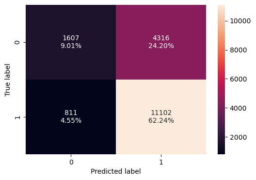

```python
confusion_matrix_sklearn(dtree_estimator, X_train, y_train)
```

```python
dtree_estimator_model_train_perf = model_performance_classification_sklearn(dtree_estimator, X_train, y_train)
dtree_estimator_model_train_perf
```

|  | Accuracy | Recall | Precision | F1 |
| --- | --- | --- | --- | --- |
| 0 | 0.712548 | 0.931923 | 0.720067 | 0.812411 |

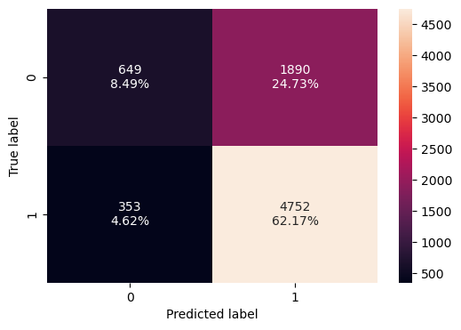

```python
confusion_matrix_sklearn(dtree_estimator, X_test, y_test)
```

```python
dtree_estimator_model_test_perf = model_performance_classification_sklearn(dtree_estimator, X_test, y_test)
dtree_estimator_model_test_perf
```

|  | Accuracy | Recall | Precision | F1 |
| --- | --- | --- | --- | --- |
| 0 | 0.706567 | 0.930852 | 0.715447 | 0.809058 |

Árbol de Decisiones Ajustado:

- Conjunto de Entrenamiento:

Las métricas presentan resultados más moderados en comparación con el modelo sin ajustar: Exactitud (0.7125), Sensibilidad (0.9319), Precisión (0.7201) y F1 (0.8124).

- Conjunto de Prueba:

El rendimiento del modelo en el conjunto de prueba es muy similar al del conjunto de entrenamiento, con una Exactitud de 0.7066, Sensibilidad de 0.9309, Precisión de 0.7154 y un F1 de 0.8091.

- Observaciones: Tras ajustar el Árbol de Decisiones, el modelo ahora presenta un equilibrio más adecuado entre el rendimiento en el conjunto de entrenamiento y de prueba, lo que indica una mejora en la generalización. Las métricas de Sensibilidad son destacables, lo que sugiere que el modelo es eficiente al identificar positivos verdaderos. Sin embargo, aún existe margen de mejora en la Exactitud y la Precisión.

## Creación de modelos de bagging y boosting

### Bagging classifier

```python
bagging_classifier = BaggingClassifier(random_state=1)
bagging_classifier.fit(X_train,y_train)
```

```
BaggingClassifier(random_state=1)
```

#### Comprobación del rendimiento del modelo en el conjunto de entrenamiento

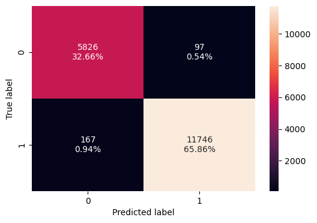

```python
confusion_matrix_sklearn(bagging_classifier, X_train, y_train)
```

```python
bagging_classifier_model_train_perf = model_performance_classification_sklearn(bagging_classifier, X_train, y_train)
bagging_classifier_model_train_perf
```

|  | Accuracy | Recall | Precision | F1 |
| --- | --- | --- | --- | --- |
| 0 | 0.985198 | 0.985982 | 0.99181 | 0.988887 |

#### Comprobación del rendimiento del modelo en el conjunto de prueba

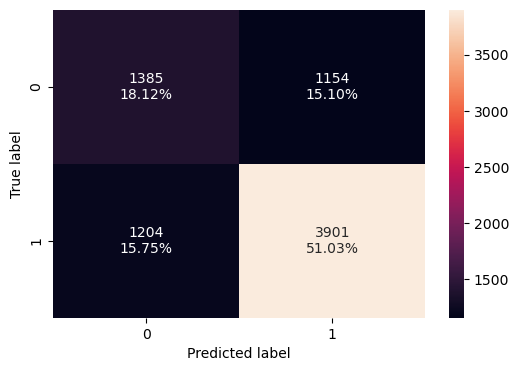

```python
confusion_matrix_sklearn(bagging_classifier, X_test, y_test)
```

```python
bagging_classifier_model_test_perf = model_performance_classification_sklearn(bagging_classifier, X_test, y_test)
bagging_classifier_model_test_perf
```

|  | Accuracy | Recall | Precision | F1 |
| --- | --- | --- | --- | --- |
| 0 | 0.691523 | 0.764153 | 0.771711 | 0.767913 |

Clasificador de Bagging Sin Ajustar:

- Conjunto de Entrenamiento:

El modelo presenta un rendimiento excepcionalmente alto con una Exactitud de 0.9852, Sensibilidad de 0.9860, Precisión de 0.9918 y F1 de 0.9889.

- Conjunto de Prueba:

Hay una notable reducción en el rendimiento al aplicar el modelo al conjunto de prueba, con una Exactitud de 0.6915, Sensibilidad de 0.7642, Precisión de 0.7717 y un F1 de 0.7679.

- Observaciones: El Clasificador de Bagging sin ajustar muestra un rendimiento sobresaliente en el conjunto de entrenamiento, lo que sugiere un posible sobreajuste. Aunque su desempeño en el conjunto de prueba es razonable, la diferencia con los resultados de entrenamiento es significativa, lo que indica la necesidad de ajustes para mejorar su capacidad de generalización. La Sensibilidad y la Precisión en el conjunto de prueba son relativamente altas, pero hay espacio para mejorar la Exactitud.

### Ajuste de hiperparámetros - bagging classifier

```python
# Choose the type of classifier.
bagging_estimator_tuned = BaggingClassifier(random_state=1)

# Grid of parameters to choose from
parameters = {
    "max_samples": [0.7, 0.9],
    "max_features": [0.7, 0.9],
    "n_estimators": np.arange(90, 111, 10),
}

# Type of scoring used to compare parameter combinations
acc_scorer = metrics.make_scorer(metrics.f1_score)

# Run the grid search
grid_obj = GridSearchCV(bagging_estimator_tuned, parameters, scoring=acc_scorer, cv=5)
grid_obj = grid_obj.fit(X_train, y_train)


bagging_estimator_tuned = grid_obj.best_estimator_


bagging_estimator_tuned.fit(X_train, y_train)
```

```
BaggingClassifier(max_features=0.7, max_samples=0.7, n_estimators=100,
                  random_state=1)
```

#### Comprobación del rendimiento del modelo en el conjunto de entrenamiento

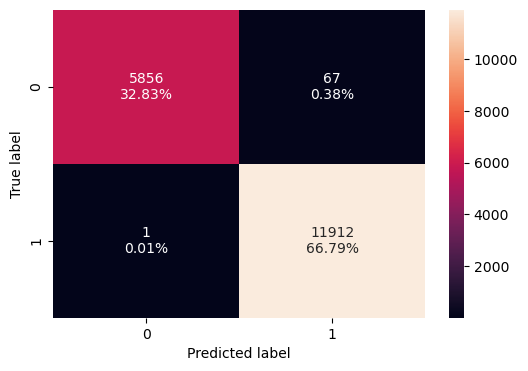

```python
confusion_matrix_sklearn(bagging_estimator_tuned, X_train, y_train)
```

```python
bagging_estimator_tuned_model_train_perf = model_performance_classification_sklearn(bagging_estimator_tuned, X_train, y_train)
bagging_estimator_tuned_model_train_perf
```

|  | Accuracy | Recall | Precision | F1 |
| --- | --- | --- | --- | --- |
| 0 | 0.996187 | 0.999916 | 0.994407 | 0.997154 |

#### Comprobación del rendimiento del modelo en el conjunto de prueba

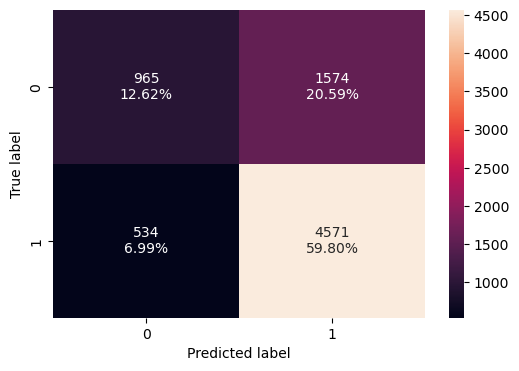

```python
confusion_matrix_sklearn(bagging_estimator_tuned, X_test, y_test)
```

```python
bagging_estimator_tuned_model_test_perf = model_performance_classification_sklearn(bagging_estimator_tuned, X_test, y_test)
bagging_estimator_tuned_model_test_perf
```

|  | Accuracy | Recall | Precision | F1 |
| --- | --- | --- | --- | --- |
| 0 | 0.724228 | 0.895397 | 0.743857 | 0.812622 |

Clasificador de Bagging Ajustado:

- Conjunto de Entrenamiento:

Después de ajustar el modelo, la exactitud en el conjunto de entrenamiento aumentó a 0.9962, con una sensibilidad casi perfecta de 0.9999, una precisión de 0.9944 y un F1 de 0.9972.

- Conjunto de Prueba:

En comparación con el modelo sin ajustar, el modelo ajustado mejora su rendimiento en el conjunto de prueba con una exactitud de 0.7242, una sensibilidad de 0.8954, una precisión de 0.7439 y un F1 de 0.8126.

### Random Forest

```python
rf_estimator = RandomForestClassifier(class_weight = "balanced", random_state=1)
rf_estimator.fit(X_train,y_train)
```

```
RandomForestClassifier(class_weight='balanced', random_state=1)
```

#### Comprobación del rendimiento del modelo en el conjunto de entrenamiento

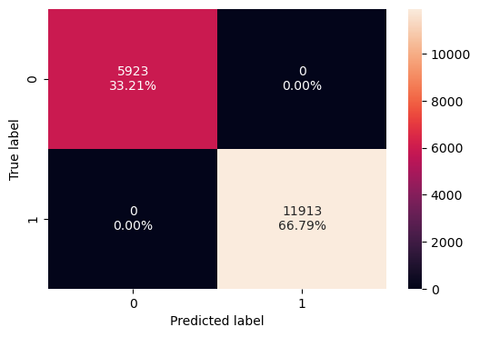

```python
confusion_matrix_sklearn(rf_estimator, X_train, y_train)
```

```python
rf_estimator_model_train_perf = model_performance_classification_sklearn(rf_estimator, X_train, y_train)
rf_estimator_model_train_perf
```

|  | Accuracy | Recall | Precision | F1 |
| --- | --- | --- | --- | --- |
| 0 | 1.0 | 1.0 | 1.0 | 1.0 |

#### Comprobación del rendimiento del modelo en el conjunto de prueba

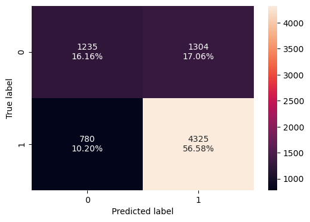

```python
confusion_matrix_sklearn(rf_estimator, X_test, y_test)
```

```python
rf_estimator_model_test_perf = model_performance_classification_sklearn(rf_estimator, X_test, y_test)
rf_estimator_model_test_perf
```

|  | Accuracy | Recall | Precision | F1 |
| --- | --- | --- | --- | --- |
| 0 | 0.727368 | 0.847209 | 0.768343 | 0.805851 |

Clasificador de Random Forest Sin Ajustar:

- Conjunto de Entrenamiento:

El modelo de Random Forest, sin ajustar, presenta un rendimiento perfecto en el conjunto de entrenamiento, alcanzando valores máximos en exactitud, sensibilidad, precisión y F1 de 1.0.

- Conjunto de Prueba:

Al evaluar el modelo en el conjunto de prueba, la exactitud es de 0.7274, con una sensibilidad de 0.8472, una precisión de 0.7683 y un F1 de 0.8059.

- Interpretación Concisa: El Random Forest sin ajustar muestra un rendimiento perfecto en entrenamiento, sugiriendo sobreajuste. Aunque las métricas en el conjunto de prueba son robustas, hay margen de mejora mediante ajustes para equilibrar el rendimiento entre entrenamiento y prueba.

### Ajuste de hiperparametros - rf

```python
# Choose the type of classifier.
rf_tuned = RandomForestClassifier(random_state=1, oob_score=True, bootstrap=True)

parameters = {
    "max_depth": list(np.arange(5, 15, 5)),
    "max_features": ["sqrt", "log2"],
    "min_samples_split": [5, 7],
    "n_estimators": np.arange(15, 26, 5),
}

# Type of scoring used to compare parameter combinations
acc_scorer = metrics.make_scorer(metrics.f1_score)

# Run the grid search
grid_obj = GridSearchCV(rf_tuned, parameters, scoring=acc_scorer,cv=5,n_jobs=-1) ## Complete the code to run grid search with cv = 5 and n_jobs = -1
grid_obj = grid_obj.fit(X_train, y_train) ## Complete the code to fit the grid_obj on the train data

# Set the clf to the best combination of parameters
rf_tuned = grid_obj.best_estimator_

# Fit the best algorithm to the data.
rf_tuned.fit(X_train, y_train)
```

```
RandomForestClassifier(max_depth=10, min_samples_split=7, n_estimators=20,
                       oob_score=True, random_state=1)
```

#### Comprobación del rendimiento del modelo en el conjunto de entrenamiento

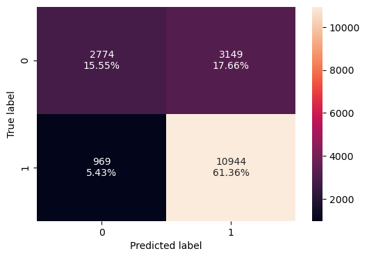

```python
confusion_matrix_sklearn(rf_tuned, X_train, y_train)
```

```python
rf_tuned_model_train_perf = model_performance_classification_sklearn(rf_tuned, X_train, y_train)
rf_tuned_model_train_perf
```

|  | Accuracy | Recall | Precision | F1 |
| --- | --- | --- | --- | --- |
| 0 | 0.769119 | 0.91866 | 0.776556 | 0.841652 |

#### Comprobación del rendimiento del modelo en el conjunto de prueba

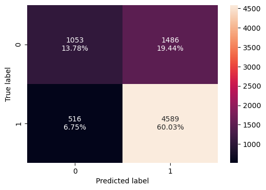

```python
confusion_matrix_sklearn(rf_tuned, X_test, y_test)
```

```python
rf_tuned_model_test_perf = model_performance_classification_sklearn(rf_tuned, X_test, y_test)
rf_tuned_model_test_perf
```

|  | Accuracy | Recall | Precision | F1 |
| --- | --- | --- | --- | --- |
| 0 | 0.738095 | 0.898923 | 0.755391 | 0.82093 |

### AdaBoost Classifier

```python
ab_classifier = AdaBoostClassifier(random_state=1)
ab_classifier.fit(X_train,y_train)
```

```
AdaBoostClassifier(random_state=1)
```

#### Comprobación del rendimiento del modelo en el conjunto de entrenamiento

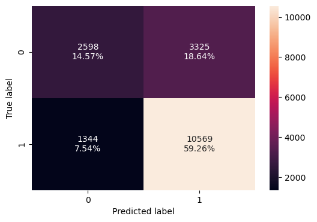

```python
confusion_matrix_sklearn(ab_classifier,X_train,y_train)
```

```python
ab_classifier_model_train_perf = model_performance_classification_sklearn(ab_classifier,X_train,y_train)
ab_classifier_model_train_perf
```

|  | Accuracy | Recall | Precision | F1 |
| --- | --- | --- | --- | --- |
| 0 | 0.738226 | 0.887182 | 0.760688 | 0.81908 |

#### Comprobacion del rendimiento del modelo en el conjunto de prueba

```python
ab_classifier_model_test_perf = model_performance_classification_sklearn(ab_classifier,X_test, y_test)
ab_classifier_model_test_perf
```

|  | Accuracy | Recall | Precision | F1 |
| --- | --- | --- | --- | --- |
| 0 | 0.734301 | 0.885015 | 0.757799 | 0.816481 |

- Conjunto de Entrenamiento:

El modelo AdaBoost muestra un rendimiento consistente en el conjunto de entrenamiento con una exactitud del 73.8%, una sensibilidad del 88.7%, una precisión del 76.1% y un F1 del 81.9%.

- Conjunto de Prueba:

Para el conjunto de prueba, la exactitud se mantiene en 73.4%, con una sensibilidad de 88.5%, una precisión de 75.8% y un F1 de 81.6%.

- Observacion:

El clasificador AdaBoost demuestra una notable estabilidad entre los conjuntos de entrenamiento y prueba. Las métricas son casi idénticas en ambos conjuntos, indicando que el modelo está bien generalizado y no sufre de sobreajuste. La alta sensibilidad refleja su capacidad para identificar correctamente los verdaderos positivos. La precisión y el F1 subrayan que el modelo mantiene un equilibrio en la predicción de ambas clases. AdaBoost parece ser un modelo fiable y estable para esta tarea.

### Ajuste de hiperparámetros - AdaBoost Classifier

```python
# Choose the type of classifier.
abc_tuned = AdaBoostClassifier(random_state=1)

# Grid of parameters to choose from
parameters = {
    # Let's try different max_depth for base_estimator
    "base_estimator": [
        DecisionTreeClassifier(max_depth=1, class_weight="balanced", random_state=1),
        DecisionTreeClassifier(max_depth=2, class_weight="balanced", random_state=1),
    ],
    "n_estimators": np.arange(80, 101, 10),
    "learning_rate": np.arange(0.1, 0.4, 0.1),
}

# Type of scoring used to compare parameter  combinations
acc_scorer = metrics.make_scorer(metrics.f1_score)

# Run the grid search
grid_obj =  GridSearchCV(abc_tuned, parameters, scoring=acc_scorer, cv=5)
grid_obj = grid_obj.fit(X_train, y_train)


abc_tuned = grid_obj.best_estimator_

# Fit the best algorithm to the data.
abc_tuned.fit(X_train, y_train)
```

```
AdaBoostClassifier(base_estimator=DecisionTreeClassifier(class_weight='balanced',
                                                         max_depth=1,
                                                         random_state=1),
                   learning_rate=0.1, n_estimators=100, random_state=1)
```

#### Comprobación del rendimiento del modelo en el conjunto de entrenamiento

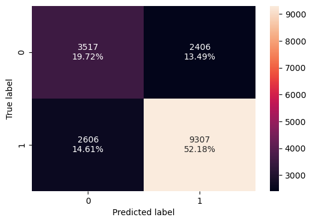

```python
confusion_matrix_sklearn(abc_tuned,X_train, y_train)
```

```python
abc_tuned_model_train_perf = model_performance_classification_sklearn(abc_tuned,X_train, y_train)
abc_tuned_model_train_perf
```

|  | Accuracy | Recall | Precision | F1 |
| --- | --- | --- | --- | --- |
| 0 | 0.718995 | 0.781247 | 0.794587 | 0.787861 |

#### Comprobación del rendimiento del modelo en el conjunto de prueba

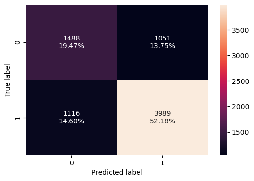

```python
confusion_matrix_sklearn(abc_tuned,X_test, y_test)
```

```python
abc_tuned_model_test_perf = model_performance_classification_sklearn(abc_tuned,X_test, y_test)
abc_tuned_model_test_perf
```

|  | Accuracy | Recall | Precision | F1 |
| --- | --- | --- | --- | --- |
| 0 | 0.71651 | 0.781391 | 0.791468 | 0.786397 |

- Conjunto de Entrenamiento:

El modelo AdaBoost ajustado tiene una exactitud del 71.9% en el conjunto de entrenamiento. La sensibilidad es del 78.1%, la precisión es del 79.5% y el F1 es del 78.8%.

- Conjunto de Prueba:

Para el conjunto de prueba, el modelo presenta una exactitud del 71.7%, una sensibilidad de 78.1%, una precisión del 79.1% y un F1 de 78.6%.

- Observacion:

Tras ajustar el clasificador AdaBoost, el rendimiento entre los conjuntos de entrenamiento y prueba es muy similar, indicando una buena generalización. Aunque hay una ligera disminución en las métricas comparado con el modelo no ajustado, este ajuste proporciona un equilibrio más homogéneo en la predicción de ambas clases, como lo sugieren la sensibilidad, precisión y F1 cercanas. El modelo ajustado de AdaBoost es coherente y fiable para la tarea en cuestión.

### Gradient boosting classifier

```python
gb_classifier = GradientBoostingClassifier(random_state=1)
gb_classifier.fit(X_train,y_train)
```

```
GradientBoostingClassifier(random_state=1)
```

#### Comprobación del rendimiento del modelo en el conjunto de entrenamiento

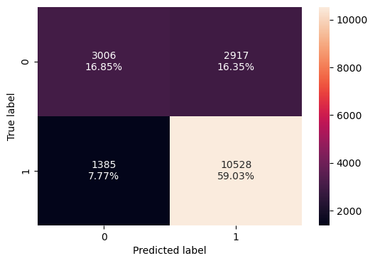

```python
confusion_matrix_sklearn(gb_classifier,X_train, y_train)
```

```python
gb_classifier_model_train_perf = model_performance_classification_sklearn(gb_classifier,X_train, y_train)
gb_classifier_model_train_perf
```

|  | Accuracy | Recall | Precision | F1 |
| --- | --- | --- | --- | --- |
| 0 | 0.758802 | 0.88374 | 0.783042 | 0.830349 |

#### Comprobación del rendimiento del modelo en el conjunto de prueba

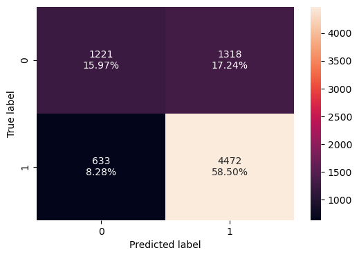

```python
confusion_matrix_sklearn(gb_classifier,X_test, y_test)
```

```python
gb_classifier_model_test_perf = model_performance_classification_sklearn(gb_classifier,X_test, y_test)
gb_classifier_model_test_perf
```

|  | Accuracy | Recall | Precision | F1 |
| --- | --- | --- | --- | --- |
| 0 | 0.744767 | 0.876004 | 0.772366 | 0.820927 |

- Conjunto de Entrenamiento:

El modelo Gradient Boosting, sin ajustar, presenta una exactitud del 75.9% en el conjunto de entrenamiento. La sensibilidad alcanza el 88.4%, la precisión es del 78.3% y el F1 es del 83.0%.

- Conjunto de Prueba:

Para el conjunto de prueba, este modelo muestra una exactitud del 74.5%, con una sensibilidad del 87.6%, una precisión del 77.2% y un F1 del 82.1%.

- Observacion:

El Gradient Boosting sin ajustar ofrece un rendimiento sólido tanto en el conjunto de entrenamiento como en el de prueba. Las métricas, especialmente la sensibilidad, sugieren que el modelo es eficiente al detectar verdaderos positivos. La similitud en el rendimiento entre ambos conjuntos indica una buena generalización del modelo a datos no vistos. La consistencia en las métricas refleja un equilibrio en la predicción de ambas clases. Es un buen punto de partida, pero podría haber espacio para optimización mediante ajustes.

### Ajuste de hiperparámetros - Gradient boost classifier

```python
# Choose the type of classifier.
gbc_tuned = GradientBoostingClassifier(
    init=AdaBoostClassifier(random_state=1), random_state=1
)

# Grid of parameters to choose from
parameters = {
    "n_estimators": [200, 250],
    "subsample": [0.9, 1],
    "max_features": [0.8, 0.9],
    "learning_rate": np.arange(0.1, 0.21, 0.1),
}

# Type of scoring used to compare parameter combinations
acc_scorer = metrics.make_scorer(metrics.f1_score)

# Run the grid search
grid_obj = GridSearchCV(gbc_tuned, parameters, scoring=acc_scorer,cv=5) ## Complete the code to run grid search with cv = 5
grid_obj = grid_obj.fit(X_train, y_train)
 ## Complete the code to fit the grid_obj on train data

# Set the clf to the best combination of parameters
gbc_tuned = grid_obj.best_estimator_

# Fit the best algorithm to the data.
gbc_tuned.fit(X_train, y_train)
```

```
GradientBoostingClassifier(init=AdaBoostClassifier(random_state=1),
                           max_features=0.8, n_estimators=200, random_state=1,
                           subsample=1)
```

#### Comprobación del rendimiento del modelo en el conjunto de entrenamiento

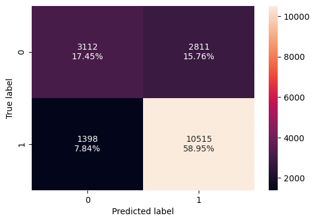

```python
confusion_matrix_sklearn(gbc_tuned, X_train, y_train)
```

```python
gbc_tuned_model_train_perf = model_performance_classification_sklearn(gbc_tuned, X_train, y_train)
gbc_tuned_model_train_perf
```

|  | Accuracy | Recall | Precision | F1 |
| --- | --- | --- | --- | --- |
| 0 | 0.764017 | 0.882649 | 0.789059 | 0.833234 |

#### Comprobación del rendimiento del modelo en el conjunto de prueba

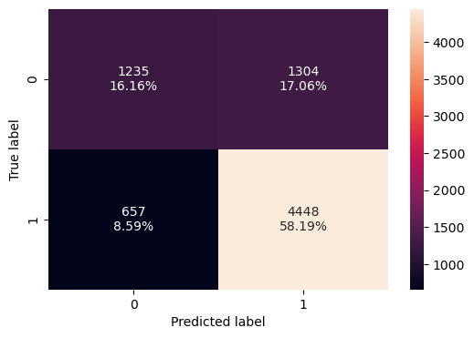

```python
confusion_matrix_sklearn(gbc_tuned, X_test, y_test)
```

```python
gbc_tuned_model_test_perf = model_performance_classification_sklearn(gbc_tuned, X_test, y_test)
gbc_tuned_model_test_perf
```

|  | Accuracy | Recall | Precision | F1 |
| --- | --- | --- | --- | --- |
| 0 | 0.743459 | 0.871303 | 0.773296 | 0.819379 |

- Conjunto de Entrenamiento:

El modelo Gradient Boosting, después de ajustar, tiene una exactitud del 76.4% en el conjunto de entrenamiento. Presenta una sensibilidad del 88.3%, una precisión del 78.9% y un F1 del 83.3%.

- Conjunto de Prueba:

Al evaluarlo en el conjunto de prueba, la exactitud es del 74.3%, con una sensibilidad del 87.1%, una precisión del 77.3% y un F1 del 81.9%.

- Observacion:

El Gradient Boosting ajustado exhibe un rendimiento levemente mejorado en el conjunto de entrenamiento, en comparación con su versión sin ajustar. Sin embargo, en el conjunto de prueba, las métricas son casi idénticas. Esto indica que los ajustes realizados lograron una pequeña optimización en el entrenamiento, pero no se tradujeron en mejoras significativas en datos no vistos. La consistencia entre entrenamiento y prueba sugiere que el modelo mantiene una buena generalización.

### XGBoost Classifier

```python
xgb_classifier = XGBClassifier(random_state=1, eval_metric='logloss')
xgb_classifier.fit(X_train,y_train)
```

```
XGBClassifier(base_score=None, booster=None, callbacks=None,
              colsample_bylevel=None, colsample_bynode=None,
              colsample_bytree=None, device=None, early_stopping_rounds=None,
              enable_categorical=False, eval_metric='logloss',
              feature_types=None, gamma=None, grow_policy=None,
              importance_type=None, interaction_constraints=None,
              learning_rate=None, max_bin=None, max_cat_threshold=None,
              max_cat_to_onehot=None, max_delta_step=None, max_depth=None,
              max_leaves=None, min_child_weight=None, missing=nan,
              monotone_constraints=None, multi_strategy=None, n_estimators=None,
              n_jobs=None, num_parallel_tree=None, random_state=1, ...)
```

#### Comprobación del rendimiento del modelo en el conjunto de entrenamiento

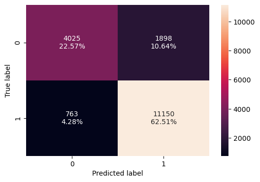

```python
confusion_matrix_sklearn(xgb_classifier,X_train, y_train)
```

```python
xgb_classifier_model_train_perf = model_performance_classification_sklearn(xgb_classifier,X_train, y_train)
xgb_classifier_model_train_perf
```

|  | Accuracy | Recall | Precision | F1 |
| --- | --- | --- | --- | --- |
| 0 | 0.850807 | 0.935952 | 0.854537 | 0.893394 |

#### Comprobación del rendimiento del modelo en el conjunto de prueba

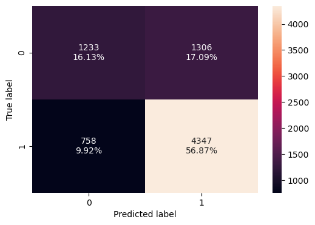

```python
confusion_matrix_sklearn(xgb_classifier,X_test, y_test)
```

```python
xgb_classifier_model_test_perf = model_performance_classification_sklearn(xgb_classifier,X_test, y_test)
xgb_classifier_model_test_perf
```

|  | Accuracy | Recall | Precision | F1 |
| --- | --- | --- | --- | --- |
| 0 | 0.729984 | 0.851518 | 0.768972 | 0.808143 |

- Conjunto de Entrenamiento:

El modelo XGBoost sin ajustar muestra una exactitud del 85.1% en el conjunto de entrenamiento. Posee una sensibilidad del 93.6%, una precisión del 85.5% y un F1 del 89.3%.

- Conjunto de Prueba:

En el conjunto de prueba, la exactitud es del 73.0%, con una sensibilidad del 85.2%, una precisión del 76.9% y un F1 del 80.8%.

- Observacion:

El modelo XGBoost sin ajustar manifiesta un excelente rendimiento en el conjunto de entrenamiento, pero su eficacia disminuye un poco en el conjunto de prueba. Aunque el desempeño sigue siendo robusto en el conjunto de prueba, la diferencia entre las métricas de entrenamiento y prueba podría indicar un ligero sobreajuste. Es recomendable considerar un ajuste para mejorar la generalización del modelo en datos no vistos, manteniendo la alta capacidad de identificación de verdaderos positivos que demuestra en la sensibilidad.